# Experiments 1 & 2: Reaction Time Analyses

Owen Morgan

June 25, 2024

## Summary

*All p-values two-sided.*

### Categorical handedness

#### Exploratory: EHI +/-100

Limiting analysis to strong left and right handers with EHI scores of {$\pm$}100, left handers’ LVF>RVF global bias was reduced by 20.49ms (95% CI [9.05, 31.93], (83,094.7) = 3.51, = .0005, two-sided). Both groups showed significant LVF global>local bias: for right handers, the effect size was 32.68ms (95% CI [24.78 ,40.57], (83,095.0) = 8.11, < .0001, two-sided); for left handers, only 12.19ms (95% CI [3.90, 20.47], (83,094.4) = 2.88, = .004, two-sided). The interaction of field by level by handedness did not differ significantly between experiments (difference = 6.03ms greater in Experiment 1, 95% CI [-16.86, 28.92], (83,094.7) = 0.52, = .61).

Within the local level, left handers showed reversed hemifield bias: right handers responded faster to local targets in the RVF than LVF by 11.86ms (95% CI [6.21, 17.51], (83,095.4) = 4.11, < .0001, two-sided), whereas left handers responded faster to local targets in the LVF than RVF by 12.99ms (95% CI [7.06, 18.91], (83,094.9) = 4.30 < .0001, two-sided; difference = 24.85ms, 95% CI [16.66, 33.04], (83,095.2) = 5.95, < .0001, two-sided). The effect of handedness on local hemifield bias did not differ significantly between experiments (difference = 13.78ms greater in Experiment 1, 95% CI [-2.61, 30.16], (83,095.1) = 1.65, = .10, two-sided).

### Continuous handedness

Combining experiments, left handedness predicted reduced LVF global>local bias (0.097ms per EHI unit, 95% CI [0.054, 0.141], (233,104.7) = 4.39, < .0001, two-sided). Strong right handers (EHI = +100) showed estimated LVF global>local bias of 37.03ms (95% CI [31.47, 42.58], (233,104.9) = 13.06, < .0001, two-sided), and strong left handers (EHI = -100) showed estimated LVF global>local bias of 17.54ms (95% CI [12.02, 23.07], (233,104.5) = 6.22, < .0001, two-sided). The interaction of field by level by handedness did not differ significantly between experiments (difference = 0.063ms per EHI unit, 95% CI [-0.024, 0.15], $\chi^2(1)$ = 1.99, = .16, two-sided).

Within the local level, left handedness predicted reversed hemifield bias (0.123ms per EHI unit, 95% CI [0.092, 0.154], (233,106.3) = 7.76, < .0001, two-sided). Strong right handers (EHI +100) showed estimated RVF local bias of 18.31 (95% CI [14.34, 22.28], (233,106.6) = 9.03, < .0001, two-sided), whereas strong left handers (EHI -100) showed estimated LVF local bias of 6.33ms (95% CI [2.38, 10.28], (233,106.1) = 3.14, = .002, two-sided). The effect of handedness on local hemifield bias did not differ between experiments (difference = 0.00ms per EHI unit, 95% CI [-0.063, 0.062], (233,106.2) = 0.01, p = .99, two-sided).

## Demographics

### Summary

Demographics, combining experiments

Summary

| N | Age (years) | Education (years) | Sex (M/F/O) |
| --- | --- | --- | --- |
| 1,957 | 29.39 (5.93) | 14.59 (2.52) | 1036/891/30 |

Demographics, combining experiments

Summary

| Handedness | N | Age (years) | Education (years) | Sex (M/F/O) | EHI |
| --- | --- | --- | --- | --- | --- |
| Left | 860 | 29.06 (5.86) | 14.75 (2.59) | 433/414/13 | -80.74 (19.35) |
| Mixed | 306 | 28.72 (6.13) | 14.69 (2.5) | 147/153/6 | -4.29 (27.13) |
| Right | 791 | 30 (5.89) | 14.37 (2.43) | 456/324/11 | 84.86 (17.22) |

Left: (EHI <= -40) | Mixed: (-40 < EHI < 40) | Right: (EHI >= 40)

Demographics by experiment

Summary

| experiment | N | Age (years) | Education (years) | Sex (M/F/O) |
| --- | --- | --- | --- | --- |
| Experiment one | 844 | 29.08 (6.03) | 14.38 (2.48) | 441/391/12 |
| Experiment two | 1,113 | 29.62 (5.85) | 14.74 (2.54) | 595/500/18 |

Demographics by experiment

Summary

| Handedness | N | Age (years) | Education (years) | Sex (M/F/O) | EHI |
| --- | --- | --- | --- | --- | --- |
| Experiment one |  |  |  |  |  |
| Left | 331 | 28.84 (6.1) | 14.45 (2.39) | 170/157/4 | -81.61 (19.27) |
| Mixed | 135 | 28.83 (6.17) | 14.58 (2.6) | 77/56/2 | -8.89 (26.49) |
| Right | 378 | 29.38 (5.93) | 14.24 (2.5) | 194/178/6 | 86.01 (16.61) |
| Experiment two |  |  |  |  |  |
| Left | 529 | 29.2 (5.7) | 14.94 (2.69) | 263/257/9 | -80.2 (19.39) |
| Mixed | 171 | 28.64 (6.11) | 14.78 (2.43) | 70/97/4 | -0.66 (27.16) |
| Right | 413 | 30.57 (5.81) | 14.48 (2.35) | 262/146/5 | 83.81 (17.72) |

Left: (EHI <= -40) | Mixed: (-40 < EHI < 40) | Right: (EHI >= 40)

### Race

Demographics, combining experiments

Race

| Race | n | pct |
| --- | --- | --- |
| White | 1,437 | 73.4 |
| Black or African American | 178 | 9.1 |
| Multiple | 166 | 8.5 |
| Asian | 153 | 7.8 |
| American Indian or Alaska Native | 12 | 0.6 |
| Native Hawaiian or Other Pacific Islander | 6 | 0.3 |
| Other | 5 | 0.3 |

Demographics, combining experiments

Ethnicity

| Hispanic ethnicity | n | pct |
| --- | --- | --- |
| No | 1,758 | 89.8 |
| Yes | 199 | 10.2 |

Demographics by experiment

Race

| Race | n | pct |
| --- | --- | --- |
| Experiment one |  |  |
| White | 606 | 71.8 |
| Black or African American | 82 | 9.7 |
| Multiple | 76 | 9 |
| Asian | 69 | 8.2 |
| American Indian or Alaska Native | 5 | 0.6 |
| Native Hawaiian or Other Pacific Islander | 3 | 0.4 |
| Other | 3 | 0.4 |
| Experiment two |  |  |
| White | 831 | 74.7 |
| Black or African American | 96 | 8.6 |
| Multiple | 90 | 8.1 |
| Asian | 84 | 7.5 |
| American Indian or Alaska Native | 7 | 0.6 |
| Native Hawaiian or Other Pacific Islander | 3 | 0.3 |
| Other | 2 | 0.2 |

Demographics by experiment

Ethnicity

| Hispanic ethnicity | n | pct |
| --- | --- | --- |
| Experiment one |  |  |
| No | 744 | 88.2 |
| Yes | 100 | 11.8 |
| Experiment two |  |  |
| No | 1,014 | 91.1 |
| Yes | 99 | 8.9 |

### Country

Demographics by experiment

Country

| Country | n |
| --- | --- |
| Experiment one |  |
| US | 844 |
| Experiment two |  |
| UK | 498 |
| US | 615 |

### EHI

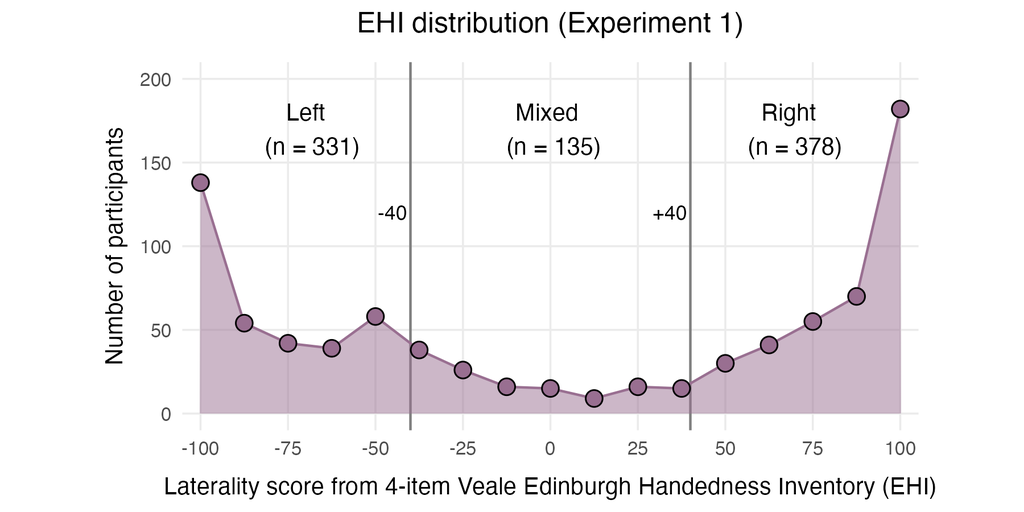

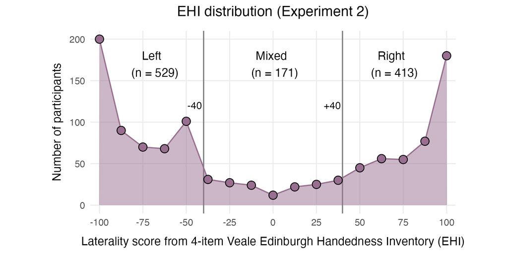

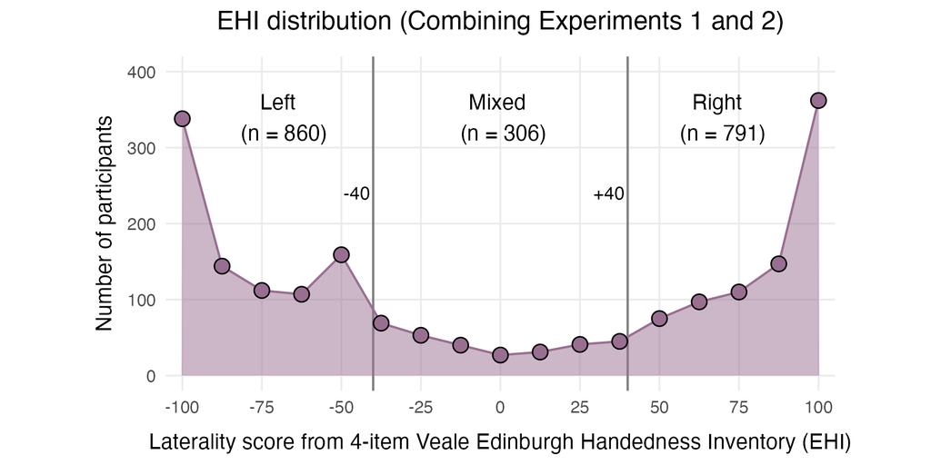

## Stats

Test for an effect of experiment on the interaction of field by level, and on the effect of field (local).

`RT ~ field * level * handedness * experiment + (1|subject) + (1|shape)`

### Categorical handedness (primary)

#### Combine experiments

Experiments 1 and 2: Field by Level by Handedness (RT)<sup>1</sup>

Compare effect estimate to zero with emmeans()<sup>1</sup>

| field_consec | level_consec | handedness_consec | estimate<sup>2</sup> | SE | df<sup>3</sup> | lower.CL<sup>4</sup> | upper.CL<sup>4</sup> | t.ratio | p.value<sup>5</sup> |
| --- | --- | --- | --- | --- | --- | --- | --- | --- | --- |
| LVF - RVF | Local - Global | Right - Left | 16.045 | 3.811 | 188,663.488 | 8.575 | 23.514 | 4.21 | <.0001 |

<sup>1</sup> Model: field * level * handedness (EHI +/-40) * experiment + (1|subject) + (1|shape)  
<sup>2</sup> A positive number means RVF local bias is stronger in right handers (as predicted by AAH)  
<sup>3</sup> Z-approximation  
<sup>4</sup> Confidence level: 95%  
<sup>5</sup> Two-sided

Experiments 1 and 2: Field by Level (by Handedness) (RT)<sup>1</sup>

| field_consec | level_consec | handedness | estimate<sup>2</sup> | SE | df<sup>3</sup> | lower.CL<sup>4</sup> | upper.CL<sup>4</sup> | t.ratio | p.value<sup>5</sup> |
| --- | --- | --- | --- | --- | --- | --- | --- | --- | --- |
| LVF - RVF | Local - Global | Left | 19.791 | 2.672 | 188,632.514 | 14.553 | 25.028 | 7.406 | <.0001 |
| LVF - RVF | Local - Global | Right | 35.836 | 2.717 | 188,693.526 | 30.51 | 41.161 | 13.189 | <.0001 |

<sup>1</sup> Model: field * level * handedness (EHI +/-40) * experiment + (1|subject) + (1|shape)  
<sup>2</sup> A positive number means RVF>LVF local>global bias  
<sup>3</sup> Z-approximation  
<sup>4</sup> Confidence level: 95%  
<sup>5</sup> Two-sided, uncorrected

Experiments 1 and 2: Field by Handedness (by Level) (RT)<sup>1</sup>

| field_consec | handedness_consec | level | estimate<sup>2</sup> | SE | df<sup>3</sup> | lower.CL<sup>4</sup> | upper.CL<sup>4</sup> | t.ratio | p.value<sup>5</sup> |
| --- | --- | --- | --- | --- | --- | --- | --- | --- | --- |
| LVF - RVF | Right - Left | Global | 4.313 | 2.666 | 188,815.521 | −0.913 | 9.539 | 1.617 | .106 |
| LVF - RVF | Right - Left | Local | 20.357 | 2.723 | 188,514.994 | 15.021 | 25.694 | 7.477 | <.0001 |

<sup>1</sup> Model: field * level * handedness (EHI +/-40) * experiment + (1|subject) + (1|shape)  
<sup>2</sup> A positive number means greater RVF bias for right handers  
<sup>3</sup> Z-approximation  
<sup>4</sup> Confidence level: 95%  
<sup>5</sup> Two-sided, uncorrected

Experiments 1 and 2: Field by (Handedness by Level) (RT)<sup>1</sup>

| contrast | handedness | level | estimate<sup>2</sup> | SE | df<sup>3</sup> | lower.CL<sup>4</sup> | upper.CL<sup>4</sup> | t.ratio | p.value<sup>5</sup> |
| --- | --- | --- | --- | --- | --- | --- | --- | --- | --- |
| LVF - RVF | Left | Global | −24.789 | 1.87 | 188,746.469 | −28.453 | −21.124 | −13.258 | <.0001 |
| LVF - RVF | Left | Local | −4.998 | 1.909 | 188,522.124 | −8.74 | −1.256 | −2.618 | .009 |
| LVF - RVF | Right | Global | −20.476 | 1.901 | 188,882.46 | −24.202 | −16.751 | −10.772 | <.0001 |
| LVF - RVF | Right | Local | 15.359 | 1.941 | 188,508.147 | 11.554 | 19.165 | 7.912 | <.0001 |

<sup>1</sup> Model: field * level * handedness (EHI +/-40) * experiment + (1|subject) + (1|shape)  
<sup>2</sup> A positive number means global bias (faster RT for global)  
<sup>3</sup> Z-approximation  
<sup>4</sup> Confidence level: 95%  
<sup>5</sup> Two-sided, uncorrected

#### Compare experiments

Experiments 1 and 2: Field by Handedness by Level (RT)

ANOVA: compare models with vs. without interaction term

| npar | AIC | BIC | logLik | deviance | Chisq | Df | p.value<sup>1</sup> |
| --- | --- | --- | --- | --- | --- | --- | --- |
| 18 | 2,689,190.307 | 2,689,373.863 | −1,344,577.153 | 2,689,154.307 | - | - | - |
| 19 | 2,689,190.905 | 2,689,384.659 | −1,344,576.453 | 2,689,152.905 | 1.401 | 1 | .237 |

<sup>1</sup> F-test (two-sided? https://daniellakens.blogspot.com/2016/04/one-sided-f-tests-and-halving-p-values.html)

Experiments 1 and 2: Field by Level by Handedness by Experiment (RT)<sup>1</sup>

Compare effect estimate to zero with emmeans()<sup>1</sup>

| field_consec | level_consec | handedness_consec | experiment_consec | estimate<sup>2</sup> | SE | df<sup>3</sup> | lower.CL<sup>4</sup> | upper.CL<sup>4</sup> | t.ratio | p.value<sup>5</sup> |
| --- | --- | --- | --- | --- | --- | --- | --- | --- | --- | --- |
| LVF - RVF | Local - Global | Right - Left | two - one | 9.022 | 7.622 | 188,663.488 | −5.917 | 23.961 | 1.184 | .237 |

<sup>1</sup> Model: field * level * handedness (EHI +/-40) * experiment + (1|subject) + (1|shape)  
<sup>2</sup> A positive number means a greater effect in Experiment 2  
<sup>3</sup> Z-approximation  
<sup>4</sup> Confidence level: 95%  
<sup>5</sup> Two-sided

Experiments 1 and 2: Field by Handedness by Experiment (by level) (RT)<sup>1</sup>

Compare effect estimate to zero with emmeans()<sup>1</sup>

| field_consec | handedness_consec | experiment_consec | level | estimate<sup>2</sup> | SE | df<sup>3</sup> | lower.CL<sup>4</sup> | upper.CL<sup>4</sup> | t.ratio | p.value<sup>5</sup> |
| --- | --- | --- | --- | --- | --- | --- | --- | --- | --- | --- |
| LVF - RVF | Right - Left | two - one | Global | −12.226 | 5.333 | 188,815.521 | −22.678 | −1.774 | −2.293 | .022 |
| LVF - RVF | Right - Left | two - one | Local | −3.204 | 5.446 | 188,514.994 | −13.877 | 7.469 | −0.588 | .556 |

<sup>1</sup> Model: field * level * handedness (EHI +/-40) * experiment + (1|subject) + (1|shape)  
<sup>2</sup> A positive number means the effect size is larger in Experiment 2  
<sup>3</sup> Z-approximation  
<sup>4</sup> Confidence level: 95%  
<sup>5</sup> Two-sided

### Categorical handedness (exploratory)

#### Combine experiments

Experiments 1 and 2: Field by Level by Handedness (RT)<sup>1</sup>

Compare effect estimate to zero with emmeans()<sup>1</sup>

| field_consec | level_consec | handedness_consec | estimate<sup>2</sup> | SE | df<sup>3</sup> | lower.CL<sup>4</sup> | upper.CL<sup>4</sup> | t.ratio | p.value<sup>5</sup> |
| --- | --- | --- | --- | --- | --- | --- | --- | --- | --- |
| LVF - RVF | Local - Global | Right - Left | 20.489 | 5.839 | 83,094.689 | 9.045 | 31.934 | 3.509 | .0005 |

<sup>1</sup> Model: field * level * handedness (EHI +/-100) * experiment + (1|subject) + (1|shape)  
<sup>2</sup> A positive number means RVF local bias is stronger in right handers (as predicted by AAH)  
<sup>3</sup> Z-approximation  
<sup>4</sup> Confidence level: 95%  
<sup>5</sup> Two-sided

Experiments 1 and 2: Field by Level (by Handedness) (RT)<sup>1</sup>

| field_consec | level_consec | handedness | estimate<sup>2</sup> | SE | df<sup>3</sup> | lower.CL<sup>4</sup> | upper.CL<sup>4</sup> | t.ratio | p.value<sup>5</sup> |
| --- | --- | --- | --- | --- | --- | --- | --- | --- | --- |
| LVF - RVF | Local - Global | Left | 12.186 | 4.228 | 83,094.415 | 3.899 | 20.473 | 2.882 | .004 |
| LVF - RVF | Local - Global | Right | 32.675 | 4.027 | 83,094.996 | 24.782 | 40.568 | 8.114 | <.0001 |

<sup>1</sup> Model: field * level * handedness (EHI +/-100) * experiment + (1|subject) + (1|shape)  
<sup>2</sup> A positive number means RVF>LVF local>global bias  
<sup>3</sup> Z-approximation  
<sup>4</sup> Confidence level: 95%  
<sup>5</sup> Two-sided, uncorrected

Experiments 1 and 2: Field by Handedness (by Level) (RT)<sup>1</sup>

| field_consec | handedness_consec | level | estimate<sup>2</sup> | SE | df<sup>3</sup> | lower.CL<sup>4</sup> | upper.CL<sup>4</sup> | t.ratio | p.value<sup>5</sup> |
| --- | --- | --- | --- | --- | --- | --- | --- | --- | --- |
| LVF - RVF | Right - Left | Global | 4.356 | 4.078 | 83,094.076 | −3.638 | 12.349 | 1.068 | .286 |
| LVF - RVF | Right - Left | Local | 24.845 | 4.179 | 83,095.151 | 16.655 | 33.035 | 5.946 | <.0001 |

<sup>1</sup> Model: field * level * handedness (EHI +/-100) * experiment + (1|subject) + (1|shape)  
<sup>2</sup> A positive number means greater RVF bias for right handers  
<sup>3</sup> Z-approximation  
<sup>4</sup> Confidence level: 95%  
<sup>5</sup> Two-sided, uncorrected

Experiments 1 and 2: Field by (Handedness by Level) (RT)<sup>1</sup>

| contrast | handedness | level | estimate<sup>2</sup> | SE | df<sup>3</sup> | lower.CL<sup>4</sup> | upper.CL<sup>4</sup> | t.ratio | p.value<sup>5</sup> |
| --- | --- | --- | --- | --- | --- | --- | --- | --- | --- |
| LVF - RVF | Left | Global | −25.171 | 2.956 | 83,093.903 | −30.965 | −19.377 | −8.515 | <.0001 |
| LVF - RVF | Left | Local | −12.985 | 3.023 | 83,094.893 | −18.91 | −7.06 | −4.295 | <.0001 |
| LVF - RVF | Right | Global | −20.816 | 2.81 | 83,094.269 | −26.322 | −15.309 | −7.409 | <.0001 |
| LVF - RVF | Right | Local | 11.86 | 2.885 | 83,095.44 | 6.205 | 17.514 | 4.111 | <.0001 |

<sup>1</sup> Model: field * level * handedness (EHI +/-100) * experiment + (1|subject) + (1|shape)  
<sup>2</sup> A positive number means global bias (faster RT for global)  
<sup>3</sup> Z-approximation  
<sup>4</sup> Confidence level: 95%  
<sup>5</sup> Two-sided, uncorrected

#### Compare experiments

Experiments 1 and 2: Field by Handedness by Level (RT)

ANOVA: compare models with vs. without interaction term

| npar | AIC | BIC | logLik | deviance | Chisq | Df | p.value<sup>1</sup> |
| --- | --- | --- | --- | --- | --- | --- | --- |
| 18 | 1,136,674.143 | 1,136,842.196 | −568,319.071 | 1,136,638.143 | - | - | - |
| 19 | 1,136,675.876 | 1,136,853.265 | −568,318.938 | 1,136,637.876 | 0.267 | 1 | .605 |

<sup>1</sup> F-test (two-sided? https://daniellakens.blogspot.com/2016/04/one-sided-f-tests-and-halving-p-values.html)

Experiments 1 and 2: Field by Level by Handedness by Experiment (RT)<sup>1</sup>

Compare effect estimate to zero with emmeans()<sup>1</sup>

| field_consec | level_consec | handedness_consec | experiment_consec | estimate<sup>2</sup> | SE | df<sup>3</sup> | lower.CL<sup>4</sup> | upper.CL<sup>4</sup> | t.ratio | p.value<sup>5</sup> |
| --- | --- | --- | --- | --- | --- | --- | --- | --- | --- | --- |
| LVF - RVF | Local - Global | Right - Left | two - one | −6.034 | 11.678 | 83,094.689 | −28.924 | 16.855 | −0.517 | .605 |

<sup>1</sup> Model: field * level * handedness (EHI +/-100) * experiment + (1|subject) + (1|shape)  
<sup>2</sup> A positive number means a greater effect in Experiment 2  
<sup>3</sup> Z-approximation  
<sup>4</sup> Confidence level: 95%  
<sup>5</sup> Two-sided

Experiments 1 and 2: Field by Handedness by Experiment (by level) (RT)<sup>1</sup>

Compare effect estimate to zero with emmeans()<sup>1</sup>

| field_consec | handedness_consec | experiment_consec | level | estimate<sup>2</sup> | SE | df<sup>3</sup> | lower.CL<sup>4</sup> | upper.CL<sup>4</sup> | t.ratio | p.value<sup>5</sup> |
| --- | --- | --- | --- | --- | --- | --- | --- | --- | --- | --- |
| LVF - RVF | Right - Left | two - one | Global | −7.741 | 8.157 | 83,094.076 | −23.728 | 8.246 | −0.949 | .343 |
| LVF - RVF | Right - Left | two - one | Local | −13.776 | 8.357 | 83,095.151 | −30.156 | 2.605 | −1.648 | .099 |

<sup>1</sup> Model: field * level * handedness (EHI +/-100) * experiment + (1|subject) + (1|shape)  
<sup>2</sup> A positive number means the effect size is larger in Experiment 2  
<sup>3</sup> Z-approximation  
<sup>4</sup> Confidence level: 95%  
<sup>5</sup> Two-sided

### Continuous handedness (primary)

#### Combine and compare experiments

Experiments 1 and 2: Field by Level by EHI (RT)<sup>1</sup>

Compare effect estimate to zero with emmeans()<sup>1</sup>

| field_consec | level_consec | estimate<sup>2</sup> | SE | df<sup>3</sup> | lower.CL<sup>4</sup> | upper.CL<sup>4</sup> | t.ratio | p.value<sup>5</sup> |
| --- | --- | --- | --- | --- | --- | --- | --- | --- |
| RVF - LVF | Global - Local | 0.097 | 0.022 | 233,104.699 | 0.054 | 0.141 | 4.385 | <.0001 |

<sup>1</sup> Model: field * level * EHI * experiment + (1|subject) + (1|shape)  
<sup>2</sup> A positive number means local bias is stronger in RVF for right handers (as predicted by AAH), in ms per EHI unit (-100 to 100). Multiply this value by 200 to get the estimated difference in LVF global bias for strong left vs. right handers.  
<sup>3</sup> Z-approximation  
<sup>4</sup> Confidence level: 95  
<sup>5</sup> Two-sided

Field by level (by EHI)

| field_consec | level_consec | ehi<sup>1</sup> | estimate<sup>2</sup> | SE | df | lower.CL | upper.CL | t.ratio | p.value |
| --- | --- | --- | --- | --- | --- | --- | --- | --- | --- |
| RVF - LVF | Global - Local | −100 | 17.544 | 2.821 | 233,104.493 | 12.015 | 23.074 | 6.219 | <.0001 |
| RVF - LVF | Global - Local | 0 | 27.287 | 1.75 | 233,104.747 | 23.857 | 30.717 | 15.593 | <.0001 |
| RVF - LVF | Global - Local | 100 | 37.029 | 2.835 | 233,104.94 | 31.472 | 42.586 | 13.06 | <.0001 |

<sup>1</sup> Strong left hander: -100; Mixed hander: 0; Strong right hander: +100  
<sup>2</sup> Estimated effect of field by level (ms); a positive number is in the direction of RVF local bias

Experiments 1 and 2: Field by Level by EHI (RT)<sup>1</sup>

Compare effect estimate to zero with emmeans()<sup>1</sup>

| field_consec | level_consec | experiment_consec | estimate<sup>2</sup> | SE | df<sup>3</sup> | lower.CL<sup>4</sup> | upper.CL<sup>4</sup> | t.ratio | p.value<sup>5</sup> |
| --- | --- | --- | --- | --- | --- | --- | --- | --- | --- |
| RVF - LVF | Global - Local | two - one | 0.063 | 0.044 | 233,104.7 | −0.024 | 0.15 | 1.409 | .159 |

<sup>1</sup> Model: field * level * EHI * experiment + (1|subject) + (1|shape)  
<sup>2</sup> A positive number means the effect of handedness on field by level (in the direction predicted by AAH) was greater in experiment 2.  
<sup>3</sup> Z-approximation  
<sup>4</sup> Confidence level: 95  
<sup>5</sup> Two-sided

Field by level by EHI by experiment (RT)<sup>1</sup>

ANOVA: compare models with vs. without interaction term<sup>1</sup>

| npar | AIC | BIC | logLik | deviance | Chisq | Df | p.value<sup>2</sup> |
| --- | --- | --- | --- | --- | --- | --- | --- |
| 18 | 3,188,730.341 | 3,188,916.959 | −1,594,347.171 | 3,188,694.341 | - | - | - |
| 19 | 3,188,730.356 | 3,188,927.341 | −1,594,346.178 | 3,188,692.356 | 1.985 | 1 | .159 |

<sup>1</sup> Model: field * level * EHI * experiment + (1|subject) + (1|shape)  
<sup>2</sup> F-test (two-sided? https://daniellakens.blogspot.com/2016/04/one-sided-f-tests-and-halving-p-values.html)

Experiments 1 and 2: Field by EHI (by Level) (RT)<sup>1</sup>

Compare effect estimate to zero with emmeans()<sup>1</sup>

| contrast | level | estimate<sup>2</sup> | SE | df<sup>3</sup> | lower.CL<sup>4</sup> | upper.CL<sup>4</sup> | t.ratio | p.value<sup>5</sup> |
| --- | --- | --- | --- | --- | --- | --- | --- | --- |
| LVF - RVF | Local | 0.123 | 0.016 | 233,106.272 | 0.092 | 0.154 | 7.759 | <.0001 |
| LVF - RVF | Global | 0.026 | 0.016 | 233,102.637 | −0.005 | 0.056 | 1.659 | .097 |

<sup>1</sup> Model: field * level * EHI * experiment + (1|subject) + (1|shape)  
<sup>2</sup> A positive number means local bias is stronger in RVF for right handers (as predicted by AAH), in ms per EHI unit (-100 to 100). Multiply this value by 200 to get the estimated difference in LVF global bias for strong left vs. right handers.  
<sup>3</sup> Z-approximation  
<sup>4</sup> Confidence level: 95  
<sup>5</sup> Two-sided

Field (by level, by EHI)

| contrast | level | ehi<sup>1</sup> | estimate<sup>2</sup> | SE | df | lower.CL | upper.CL | t.ratio | p.value |
| --- | --- | --- | --- | --- | --- | --- | --- | --- | --- |
| LVF - RVF | Local | −100 | −6.334 | 2.016 | 233,106.139 | −10.284 | −2.383 | −3.142 | .002 |
| LVF - RVF | Global | −100 | −23.878 | 1.974 | 233,102.605 | −27.746 | −20.009 | −12.097 | <.0001 |
| LVF - RVF | Local | 0 | 5.987 | 1.25 | 233,106.486 | 3.536 | 8.437 | 4.788 | <.0001 |
| LVF - RVF | Global | 0 | −21.3 | 1.224 | 233,102.491 | −23.7 | −18.9 | −17.397 | <.0001 |
| LVF - RVF | Local | 100 | 18.307 | 2.026 | 233,106.566 | 14.335 | 22.279 | 9.034 | <.0001 |
| LVF - RVF | Global | 100 | −18.722 | 1.983 | 233,102.557 | −22.609 | −14.836 | −9.442 | <.0001 |

<sup>1</sup> Strong left hander: -100; Mixed hander: 0; Strong right hander: +100  
<sup>2</sup> Estimated effect of field (ms); a positive number is in the direction of RVF bias

Experiments 1 and 2: Field by EHI by Experiment (by level) (RT)<sup>1</sup>

Compare effect estimate to zero with emmeans()<sup>1</sup>

| field_consec | experiment_consec | level | estimate<sup>2</sup> | SE | df<sup>3</sup> | lower.CL<sup>4</sup> | upper.CL<sup>4</sup> | t.ratio | p.value<sup>5</sup> |
| --- | --- | --- | --- | --- | --- | --- | --- | --- | --- |
| RVF - LVF | two - one | Local | 0 | 0.032 | 233,106.272 | −0.063 | 0.062 | −0.012 | .991 |
| RVF - LVF | two - one | Global | 0.062 | 0.031 | 233,102.637 | 0.001 | 0.123 | 2.003 | .045 |

<sup>1</sup> Model: field * level * EHI * experiment + (1|subject) + (1|shape)  
<sup>2</sup> A positive number means the effect of handedness on field by level (in the direction predicted by AAH) was greater in experiment 2.  
<sup>3</sup> Z-approximation  
<sup>4</sup> Confidence level: 95  
<sup>5</sup> Two-sided

## Plots

Diamonds and lineranges show mixed-effects model point estimates and 95% CI.

### Categorical handedness (primary)

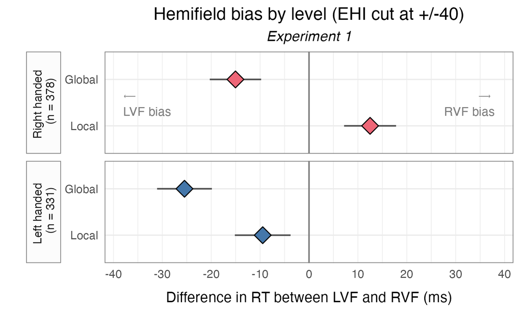

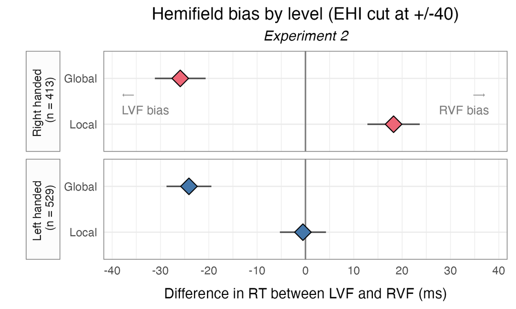

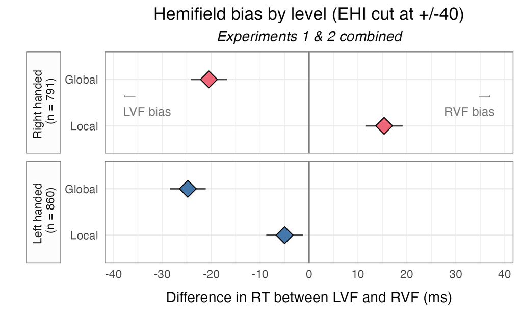

### Categorical handedness (exploratory)

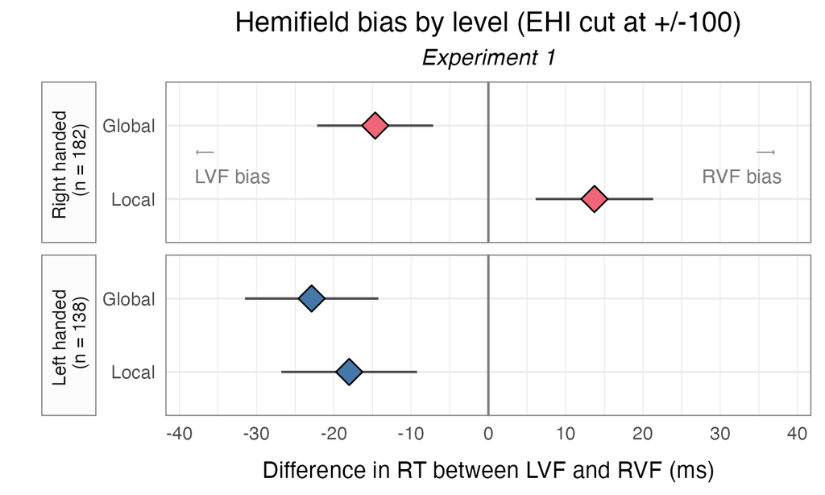

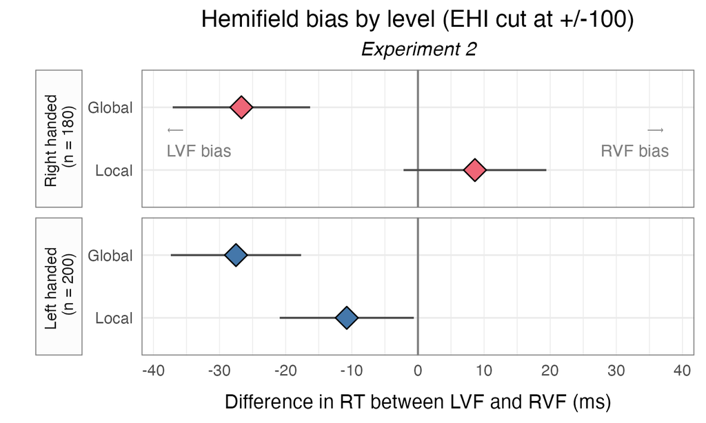

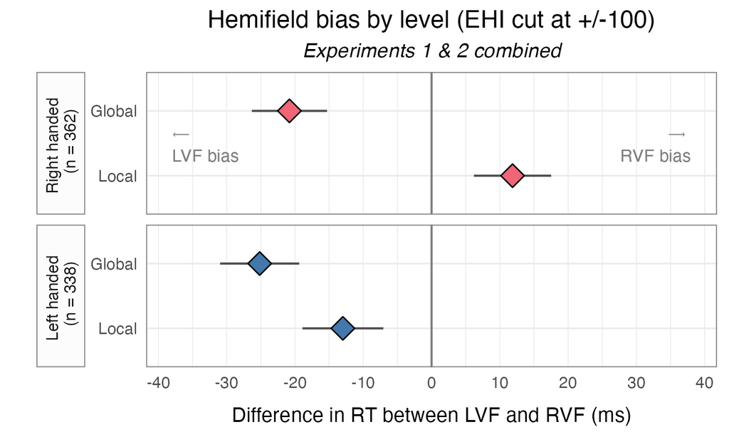

### Continuous handedness (primary)

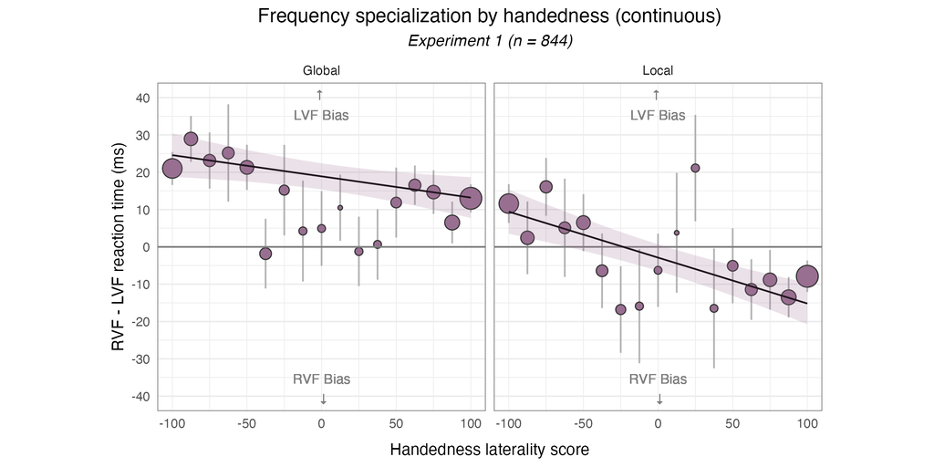

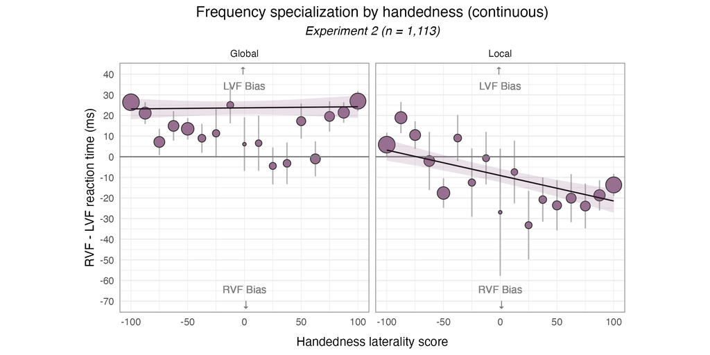

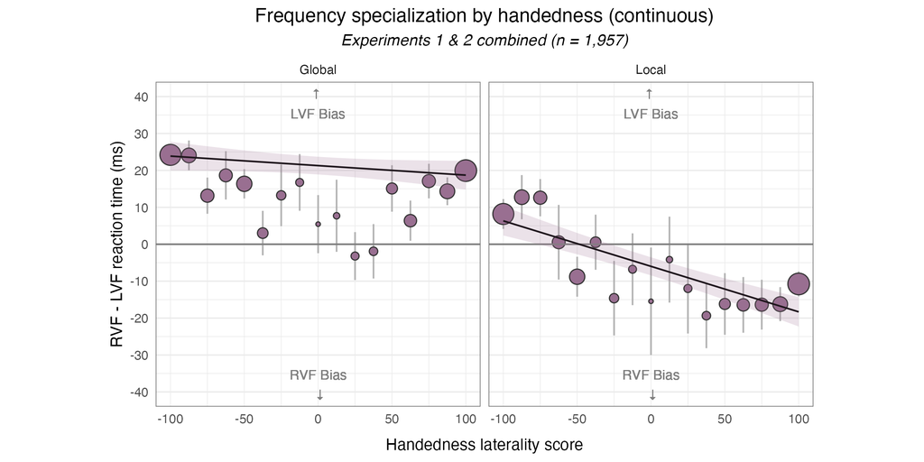